# Butterfly Wings

Last Updated: September 30, 2024 08:28:50

### To study whether temperature and wing length are related, start with a scatterplot of wing length versus temperature

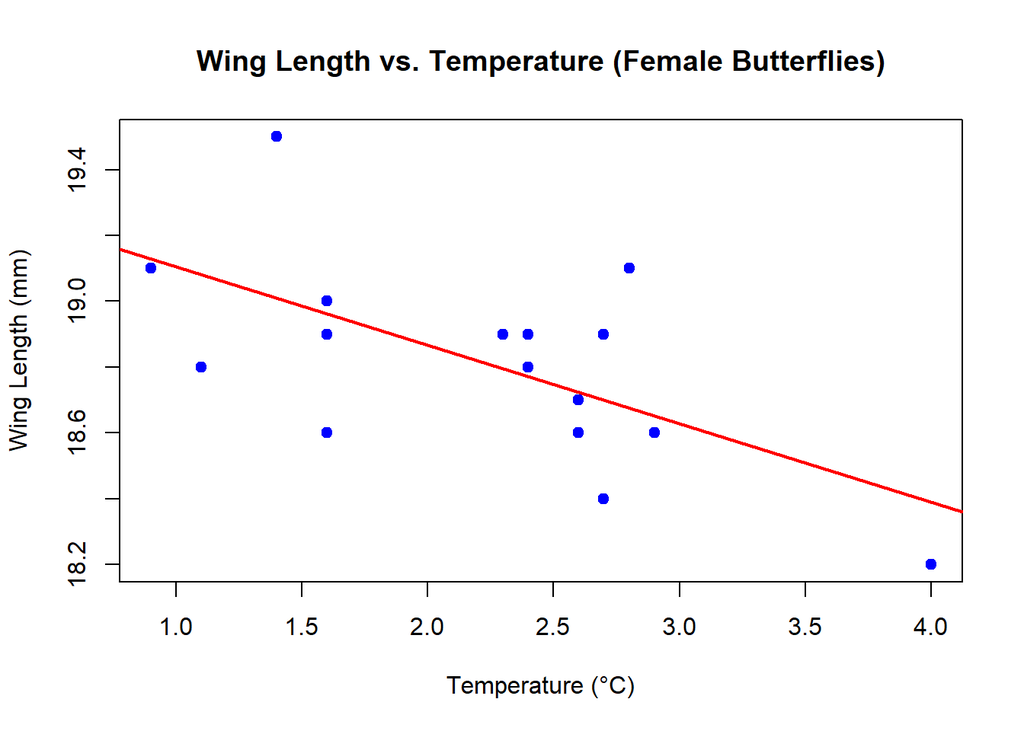

```r
plot(Temp, Wing, main = "Wing Length vs. Temperature (Female Butterflies)", xlab = "Temperature (°C)", ylab = "Wing Length (mm)", pch = 19, col = "blue")
abline(lm(Wing ~ Temp), col = "red", lwd = 2)
```

### If the data seem to follow a roughly linear pattern, find a linear model to capture the trend

```r
model <- lm(Wing ~ Temp)
summary(model)
```

```
##
## Call:
## lm(formula = Wing ~ Temp)
##
## Residuals:
##      Min       1Q   Median       3Q      Max
## -0.36176 -0.13936 -0.02594  0.11138  0.49048
##
## Coefficients:
##             Estimate Std. Error t value Pr(>|t|)
## (Intercept) 19.34386    0.18721 103.326  < 2e-16 ***
## Temp        -0.23881    0.07946  -3.006  0.00945 **
## ---
## Signif. codes:  0 '***' 0.001 '**' 0.01 '*' 0.05 '.' 0.1 ' ' 1
##
## Residual standard error: 0.2463 on 14 degrees of freedom
## Multiple R-squared:  0.3922, Adjusted R-squared:  0.3488
## F-statistic: 9.033 on 1 and 14 DF,  p-value: 0.009447
```

### What linear model did you choose?

```r
model
```

```
##
## Call:
## lm(formula = Wing ~ Temp)
##
## Coefficients:
## (Intercept)         Temp
##     19.3439      -0.2388
```

### What does your model show in terms of variability?

```r
anova(model)
```

```
## Analysis of Variance Table
##
## Response: Wing
##           Df  Sum Sq Mean Sq F value   Pr(>F)
## Temp       1 0.54808 0.54808  9.0333 0.009447 **
## Residuals 14 0.84942 0.06067
## ---
## Signif. codes:  0 '***' 0.001 '**' 0.01 '*' 0.05 '.' 0.1 ' ' 1
```

### Analyze your residuals

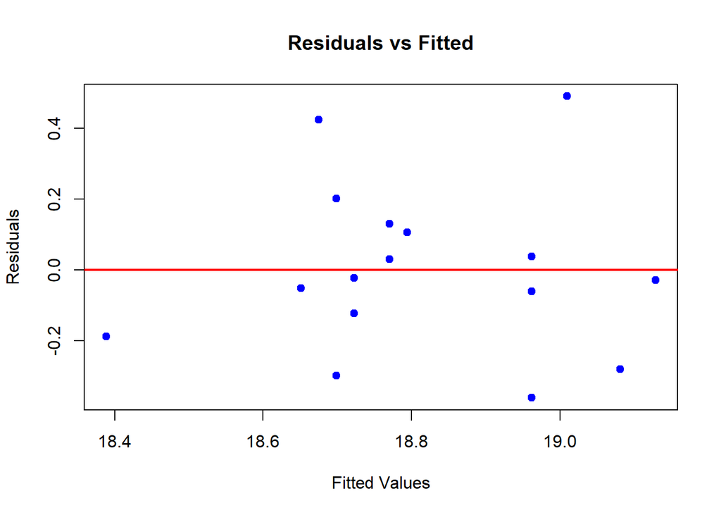

```r
plot(model$fitted.values, model$residuals, main = "Residuals vs Fitted", xlab = "Fitted Values", ylab = "Residuals", pch = 19, col = "blue")
abline(h = 0, col = "red", lwd = 2)
```

### Are any of your residuals outliers?

```r
identify_outliers <- function(residuals) {
  Q1 <- quantile(residuals, 0.25)
  Q3 <- quantile(residuals, 0.75)
  IQR <- Q3 - Q1
  lower_bound <- Q1 - 1.5 * IQR
  upper_bound <- Q3 + 1.5 * IQR
  outliers <- residuals[residuals < lower_bound | residuals > upper_bound]
  return(outliers)
}

outliers <- identify_outliers(model$residuals)
outliers
```

```
##         3
## 0.4904787
```

### Does a test of the relationship show that the linear relationship is stronger than would happen by chance if your variables were not related?

```r
cor(Temp, Wing)
```

```
## [1] -0.6262462
```

```r
cor.test(Temp, Wing)
```

```
##
##  Pearson's product-moment correlation
##
## data:  Temp and Wing
## t = -3.0055, df = 14, p-value = 0.009447
## alternative hypothesis: true correlation is not equal to 0
## 95 percent confidence interval:
##  -0.8561682 -0.1893086
## sample estimates:
##        cor
## -0.6262462
```

### What proportion of variability in your response is explained by the model you chose?

```r
summary(model)$r.squared
```

```
## [1] 0.3921843
```

### It is likely that your model is not perfect, but discuss what makes it a good model

```r
summary(model)
```

```
##
## Call:
## lm(formula = Wing ~ Temp)
##
## Residuals:
##      Min       1Q   Median       3Q      Max
## -0.36176 -0.13936 -0.02594  0.11138  0.49048
##
## Coefficients:
##             Estimate Std. Error t value Pr(>|t|)
## (Intercept) 19.34386    0.18721 103.326  < 2e-16 ***
## Temp        -0.23881    0.07946  -3.006  0.00945 **
## ---
## Signif. codes:  0 '***' 0.001 '**' 0.01 '*' 0.05 '.' 0.1 ' ' 1
##
## Residual standard error: 0.2463 on 14 degrees of freedom
## Multiple R-squared:  0.3922, Adjusted R-squared:  0.3488
## F-statistic: 9.033 on 1 and 14 DF,  p-value: 0.009447
```

### On average, how much does your response value change as your explanatory values vary?

```r
summary(model)$coefficients
```

```
##               Estimate Std. Error    t value     Pr(>|t|)
## (Intercept) 19.3438606 0.18721108 103.326471 1.384606e-21
## Temp        -0.2388137 0.07945773  -3.005544 9.447115e-03
```

Building on your study, there could be other factors (like cloud cover and rainfall) that affect both temperatures and butterfly growth. Suppose we learn that the temperature in Greenland this summer is 3.0 degrees (Celsius).

### What size of female butterfly (of this species) do we expect to see next year?

```r
predict(model, data.frame(Temp = 3.0), interval = "confidence")
```

```
##        fit      lwr     upr
## 1 18.62742 18.44064 18.8142
```